# WARC_metadata slides

**Webarchive, Metadaten und Forschung**  
Impulsbeitrag SDC-AG Metadaten, 17.02.2022  
*Julian Dörr, BERD@BW*

**Archivierung von Webseiten**

- **World Wide Web verändert sich stetig über die Zeit**:
  - Webseiten werden gelöscht
  - neue Webseiten entstehen
  - Inhalte einer Webseite werden verändert
- Gefahr des **Wissens-/Informationsverlust**?
- **Webarchive** sichern historische Informationen aus dem World Wide Web

[figure not shown]

- **Webarchive zusammengefasst**:
  - Ziel: **Langzeitarchivierung** digitaler Daten in **frei zugänglich**er Form
  - Web-Archivierung durch sogenannte **Mementos**, d.h. automatisierte **Momentaufnahmen von Webseiten** (Crawling)
  - gespeichert im standardisierten **Web ARChive (WARC)** Format
  - umfasst alle Formen von Webinhalten (Text, Bild, Video, Software, ...)

**Metadaten einer archivierten Webseite**

**Crawl/Capture inDeX** (CDX):

- erlaubt eindeutige Referenzierung einer Momentaufnahme
- **Metadaten einer Momentaufnahme** zusammengefasst in einem Index
- Grundlage für API zu Webarchiven

**Beispiel: Ein Memento von [tagesschau.de](https://web.archive.org/web/20000816064435/http://www.tagesschau.de/)**

[interactive chart not shown]

Beispiel: Ein Memento von [tagesschau.de](https://web.archive.org/web/20000816064435/http://www.tagesschau.de/)  
... und seine Metadaten

Die wichtigsten Metadaten:

- **urlkey**: `de,tagesschau)/`
- **timestamp**: `20000816064435`

Weitere Metadaten (für API Abfrage):

**Metadaten als Forschungsgegenstand?**

- **timestamp** verleiht dem Web eine **zeitliche Dimension**
- **urlkey** ermöglicht eine **inhaltliche Eingrenzung** der Webseiteninhalte

> By focusing on creating a “representative sample” of the web at large, rather than attempting to capture a single site in its entirety [...], the crawl self-limits itself to being applicable [...] to macro-level research examining web scale questions.

> -- Sara Crouse, Director, Common Crawl
- Wie verändert sich die Verwendung von Sprache im Web über die Zeit?
- Wie lange dauert es bis sich die Inhalte einer Webseite verändern?
- Können thematische Verlagerung im Web über die Zeit beobachtet werden?

**Beispiel: Kommunikation auf Unternehmenswebseiten**

```python
dax_cdx.sample(3)
```

|  | firm | year | urlkey | timestamp | original | mimetype | statuscode | digest | length | csr_url |
| --- | --- | --- | --- | --- | --- | --- | --- | --- | --- | --- |
| 353327 | siemens.com/* | 2010 | com,siemens)/answers/cc/en/index.htm | 20100303165936 | http://www.siemens.com:80/answers/cc/en/index.... | text/html | 200 | OBH4PPPZ4UQWAYVNSPAJWGAQX47FJKFF | 6878 | False |
| 184564 | telekom.com/* | 2018 | com,telekom)/de/medien/medieninformationen/det... | 20180312225836 | https://www.telekom.com/de/medien/medieninform... | text/html | 200 | 5ZXPYABWKHKW5Q4NNPIFEWIEFAFQPZ4I | 13650 | False |
| 210928 | fresenius.de/* | 2005 | de,fresenius)/e/2/e_02_4.html | 20050211034333 | http://www.fresenius.de:80/e/2/e_02_4.html | text/html | 200 | UXPKXNPLX5SGDLNLVQR462TUQLPJ7HAT | 3588 | False |

Einführung einer (unvollständigen) Schlagwortliste zum Thema "Nachhaltigkeit" ...

```python
csr_list = ['sustain', 'nachhaltig']
```

... mit anschließender Schlagwortsuche in den **urlkeys**

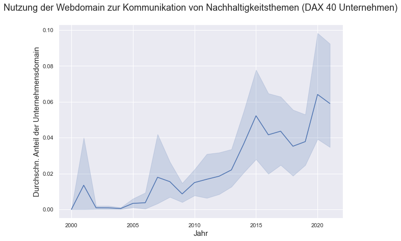

- **Analyse basiert ausschließlich auf Metadaten**
- Möglichkeit über Webseiten*inhalte* (z.B. Textdaten) tiefergehende Forschungsfragen zu beantworten?

**Herausforderung Webarchive**

- Skalierung
- Unvollständigkeit/Selektion
- rechtliche Rahmenbedingungen

**Zusammenfassung**

- Webarchive verleihen dem Web ein "zeitliches Gedächtnis"
- Nutzbarkeit als Forschungsdaten möglich aber nicht ohne Herausforderungen
- Metadaten können als Grundlage für Forschungsfragen dienen

**Vielen Dank für Ihre Aufmerksamkeit!**

**Appendix**

## Filterkriterien Archivabfrage

```
'collapse': 'urlkey',
 'filter': ['statuscode:200', 'mimetype:text/html']
```

## Anzahl der Mementos pro Unternehmen-Jahres Kombination

```python
pd.pivot_table(dax_cdx[['firm', 'year']], index=['firm'], columns=['year'], aggfunc=lambda x: str(len(x)), fill_value='')
```

| year firm | 2000 | 2001 | 2002 | 2003 | 2004 | 2005 | 2006 | 2007 | 2008 | 2009 | ... | 2012 | 2013 | 2014 | 2015 | 2016 | 2017 | 2018 | 2019 | 2020 | 2021 |
| --- | --- | --- | --- | --- | --- | --- | --- | --- | --- | --- | --- | --- | --- | --- | --- | --- | --- | --- | --- | --- | --- |
| adidas-group.com/* |  |  |  |  |  | 193 | 1000 |  | 118 | 964 | ... | 1000 |  | 831 | 1000 | 1000 | 797 | 235 | 173 | 947 | 1000 |
| airbus.com/* | 406 | 471 | 838 | 1000 | 1000 | 1000 | 1000 | 1000 | 1000 | 1000 | ... | 1000 | 1000 | 1000 | 1000 |  | 1000 | 1000 | 1000 | 1000 | 1000 |
| allianz.com/* | 73 | 1000 | 1000 | 1000 | 1000 | 1000 | 1000 | 1000 | 1000 | 1000 | ... | 1000 | 8 | 8 | 10 | 1 | 189 | 117 |  | 1000 | 1000 |
| basf.com/* | 1000 | 1000 | 1000 | 1000 | 1000 | 1000 | 1000 | 1000 |  | 1 | ... | 190 | 109 | 279 | 573 | 89 | 1000 |  | 908 | 1000 | 1000 |
| bayer.de/* | 226 |  | 1000 | 1000 | 1000 | 1000 | 1000 | 418 | 580 | 283 | ... | 376 | 363 | 306 | 388 | 361 | 282 | 239 | 283 | 312 |  |
| beiersdorf.de/* | 970 | 258 | 439 | 642 | 640 | 714 | 355 | 784 | 758 | 913 | ... | 729 | 671 | 495 | 536 |  | 813 | 36 | 227 | 1000 | 754 |
| bmwgroup.com/* | 60 | 1000 | 1000 | 1000 | 1000 | 1000 | 1000 | 1000 | 1000 |  | ... | 1000 | 1000 | 1000 | 1000 | 1000 | 412 | 232 | 251 | 893 | 1000 |
| brenntag.com/* | 2 | 412 | 1000 | 1000 | 1000 | 914 | 322 |  | 390 | 184 | ... | 265 | 300 | 234 | 546 |  | 1000 | 1000 | 258 |  | 1000 |
| continental.com/* | 1000 | 1000 | 1000 | 1000 | 465 | 286 | 1000 | 1000 | 1000 | 1000 | ... | 1000 |  |  |  |  |  |  | 375 | 1000 | 1000 |
| corporate.zalando.com/* |  |  |  |  |  |  |  |  |  |  | ... |  |  | 5 | 107 | 247 | 275 | 162 | 281 | 1000 | 1000 |
| covestro.com/* |  |  |  |  |  |  |  |  |  |  | ... |  | 1 |  | 328 | 593 | 568 | 150 | 226 | 1000 | 1000 |
| deliveryhero.com/* |  |  |  |  |  |  |  |  |  |  | ... | 41 | 26 | 68 | 50 | 65 |  | 111 | 342 | 424 | 365 |
| deutsche-bank.de/* | 24 | 48 | 631 | 1000 | 1000 | 1000 | 1000 | 1000 | 1000 | 1000 | ... | 1000 | 722 | 1000 | 1000 | 468 | 405 | 412 | 311 |  | 1000 |
| deutsche-boerse.com/* |  | 1000 | 1000 | 1000 | 1000 | 496 | 1000 | 1000 | 1000 | 1000 | ... | 1000 |  | 1000 | 1000 | 1000 | 1000 | 1000 | 1000 | 1000 | 1000 |
| dpdhl.com/* |  |  |  |  |  |  |  |  |  | 386 | ... |  | 1000 | 1000 | 1000 | 1000 | 1000 | 1000 | 424 | 960 | 1000 |
| eon.com/* | 189 | 1000 | 1000 | 80 | 99 | 167 | 1000 | 1000 | 1000 | 1000 | ... | 1000 | 1000 | 1000 | 1000 | 1000 | 1000 | 264 | 938 | 1000 | 1000 |
| fresenius.de/* | 490 | 1000 | 1000 | 1000 | 1000 | 1000 | 238 | 463 | 617 | 703 | ... | 1000 | 456 | 456 | 605 | 101 | 142 | 28 | 152 | 389 | 344 |
| freseniusmedicalcare.com/* |  | 362 |  | 165 | 276 | 11 | 13 | 7 | 15 | 91 | ... |  |  | 1 | 72 |  | 445 | 197 | 328 | 881 | 847 |
| group.rwe/* |  |  |  |  |  |  |  |  |  |  | ... |  |  |  |  |  |  | 58 | 466 | 1000 | 1000 |
| heidelbergcement.com/* |  | 52 | 755 | 1000 |  | 1000 | 1000 | 1000 | 1000 | 1000 | ... | 1000 | 1000 |  | 1000 | 1000 | 1000 | 480 | 374 | 421 | 486 |
| hellofresh.de/* |  |  |  |  |  |  |  |  |  |  | ... | 140 | 288 | 292 | 71 | 63 | 52 | 173 | 125 | 1000 | 1000 |
| henkel.de/* | 289 | 321 | 1000 | 1000 | 1000 | 1000 | 1000 | 1000 | 1000 | 1000 | ... | 1000 | 1000 | 1000 | 1000 | 1000 | 1000 | 246 | 444 | 1000 | 1000 |
| infineon.com/* | 1000 | 1000 | 1000 | 1000 | 1000 | 1000 | 1000 | 1000 | 1000 | 1000 | ... | 1000 | 1000 | 1000 | 1000 | 1000 | 1000 |  | 976 | 1000 | 1000 |
| lindeplc.com/* |  |  |  |  |  |  |  |  |  |  | ... |  |  |  |  |  |  |  | 1 |  |  |
| merckgroup.com/* |  |  |  | 1 | 1 |  |  | 40 |  |  | ... | 529 | 116 | 196 | 206 | 209 | 208 | 13 | 23 | 255 | 1000 |
| mtu.de/* |  | 320 | 4 | 9 | 1000 | 1000 | 992 | 1000 | 631 | 969 | ... | 981 | 941 | 1000 | 818 | 1000 | 1000 | 888 | 803 | 1000 | 766 |
| munichre.com/* | 198 | 555 | 911 | 53 | 37 | 530 | 1000 | 1000 | 1000 | 1000 | ... |  | 1000 | 1000 | 1000 |  | 967 |  | 1000 | 1000 | 1000 |
| porsche-se.com/* |  |  |  |  |  |  |  | 27 | 213 | 236 | ... | 218 | 216 |  | 162 | 368 | 84 | 18 | 70 | 873 | 106 |
| puma.de/* | 15 | 207 | 775 | 537 | 452 | 36 | 9 | 6 | 1 |  | ... | 1 |  |  |  |  |  | 1 |  |  |  |
| qiagen.com/* | 39 | 123 | 156 | 352 | 193 | 367 | 403 | 239 | 15 | 11 | ... | 77 | 251 | 454 | 57 | 53 | 1000 | 204 | 159 | 1000 | 1000 |
| sap.de/* |  |  |  |  | 6 | 6 | 1 | 6 |  |  | ... |  |  |  |  |  |  |  |  |  |  |
| sartorius.com/* | 252 | 1000 |  | 1000 |  | 1000 | 1000 | 1000 |  | 293 | ... | 1000 | 1000 | 1000 | 1000 | 1000 | 35 | 25 | 647 | 1000 | 1000 |
| siemens-energy.com/* |  |  |  |  |  |  |  |  |  |  | ... |  | 1 | 2 |  |  |  |  |  | 1000 | 1000 |
| siemens-healthineers.com/* |  |  |  |  |  |  |  |  |  |  | ... |  |  |  |  |  |  |  | 836 | 1000 | 1000 |
| siemens.com/* | 1000 | 1000 | 1000 | 1000 | 196 | 1000 | 1000 | 1000 | 1000 | 2 | ... | 1000 | 1000 | 1000 | 1000 | 1000 | 1000 | 1000 | 216 | 815 | 1000 |
| symrise.com/* |  |  |  | 302 | 618 | 607 | 556 | 202 | 70 |  | ... | 203 | 184 | 393 | 1000 | 975 | 492 | 29 |  | 664 | 846 |
| telekom.com/* |  | 15 | 12 | 7 | 10 | 7 | 2 | 1000 | 1000 | 1000 | ... | 1000 | 1000 | 1000 | 1000 | 1000 | 985 | 1000 | 1000 | 1000 | 1000 |
| volkswagenag.com/* |  |  | 1 | 75 | 126 |  |  | 913 | 1000 | 372 | ... |  | 475 | 736 | 1000 | 1000 | 837 | 680 | 1000 | 1000 | 1000 |
| vonovia.de/* |  |  |  |  |  |  |  |  |  |  | ... |  |  |  | 54 | 312 | 223 | 259 |  | 659 | 1000 |

39 rows × 22 columns